# Travel in big data

B0344218葉建夆 B0344117沈庭安

2017年6月9日

=================================================================

一、資料介紹、來源及格式

1.桃園國際機場即時航班(6/5-6/7):  
>桃園國際機場每天更新，當天及其前後兩天之航班狀況，當中包含往來地點、時間等資料  
>X0605_0607  
>CSV檔案  
>http://data.gov.tw/node/26194

2.中華民國國民出國目的地人數統計(2016):  
>中華民國國民歷年來到各國家的人數統計  
>aborad(taiwan2016)  
>excel檔案  
>http://admin.taiwan.net.tw/statistics/year.aspx?no=134

3.日本國內航班資料:  
>日本境內航班近年來變化的狀況  
>除上述兩檔案以外excel檔案  
>excel檔案  
>http://www.data.go.jp  
=================================================================

二、分析議題  
1.桃園機場各航空公司之航班的延誤比例  
2.台灣到各國旅遊的分布圖 3.台灣到日本近年來旅遊人數的變化  
4.日本國內近年來旅遊人數的變化

=================================================================

三、假設  
1.航班出境誤點跟入境誤點呈正相關  
2.台灣人到亞洲旅遊人數會比他洲高，尤其日韓及中國  
3.台灣到日本旅遊人數會受到天災人禍影響(2011年311大地震)  
4.311災區在2011年旅遊人數明顯下降

=================================================================

四、分析過程

## 載入需要用到的packages

```r
library(readr)
library(readxl)
library(magrittr)
library(ggmap)
library(ggplot2)
```

## 載入資料

```r
X0605_0607 <- read_csv("C:/Users/pig98/Desktop/FinalProject/0605_0607.csv",
                       col_names = FALSE)
#桃園機場的CSV檔單獨讀入

temp = list.files(pattern="*.xls")
for (i in 1:length(temp))
  assign(temp[i], read_excel(temp[i]))
#其餘excel資料用迴圈讀入
```

## 資料清洗

```r
#去除不需要的欄位以及中文名稱
X0605_0607<-X0605_0607[,c(-4,-11,-13,-14,-17,-18)]
#新增欄位名稱
colnames(X0605_0607)=c("terminals","species","airline_id","flight","gate",
                       "scheduled_date","scheduled_time","expected_date","expected_time",
                       "destination","model","other destination","baggage claim","counter")
#依照航空公司代碼簡單排序資料
X0605_0607<-X0605_0607[order(X0605_0607$airline_id),]

knitr::kable(X0605_0607)
```

[output not shown]

[output cut: 3103 more lines]

## 資料分析1:哪些航空公司的班機最容易誤點/最準時

```r
#新增一個欄位判斷班機是否delay
for(n in 1:nrow(X0605_0607) )
{
  if(X0605_0607[n,6]==X0605_0607[n,8]){
    if(X0605_0607[n,7]<X0605_0607[n,9]){
      X0605_0607$delay[n]="T"
    }else
      X0605_0607$delay[n]="F"
  }
  else if(X0605_0607[n,6]<X0605_0607[n,8])
    X0605_0607$delay[n]="T"
  else if(X0605_0607[n,6]>X0605_0607[n,8])
    X0605_0607$delay[n]="F"
}
knitr::kable(X0605_0607)
```

[output not shown]

[output cut: 3103 more lines]

```r
#將資料分成出境跟入境兩個子集
arrive<-subset(X0605_0607,species=="A");
depart<-subset(X0605_0607,species=="D");

#用table統計出各航空公司的有/無delay次數,並轉為dataframe
arrive_delay<-table(airline=arrive$airline_id,delay=arrive$delay)%>%as.data.frame.matrix()
depart_delay<-table(airline=depart$airline_id,delay=depart$delay)%>%as.data.frame.matrix()

#整理出各航空公司的航班數
flight_num<-table(airline=X0605_0607$airline_id,species=X0605_0607$species)%>%as.data.frame.matrix()
flight_num<-flight_num[order(flight_num$A+flight_num$D,decreasing = T),]
#檢視各航空公司的航班數
knitr::kable(flight_num)
```

|  | A | D |
| --- | --- | --- |
| CI | 269 | 266 |
| BR | 253 | 250 |
| JL | 65 | 65 |
| CX | 64 | 64 |
| TG | 56 | 53 |
| IT | 49 | 49 |
| KA | 49 | 49 |
| SQ | 50 | 48 |
| DL | 46 | 47 |
| CZ | 45 | 44 |
| MU | 42 | 42 |
| NH | 42 | 42 |
| HX | 38 | 38 |
| CA | 31 | 31 |
| B7 | 29 | 29 |
| AE | 27 | 27 |
| KE | 23 | 26 |
| KL | 22 | 26 |
| OZ | 20 | 20 |
| VN | 19 | 19 |
| JW | 18 | 19 |
| MM | 18 | 18 |
| MH | 17 | 17 |
| AI | 17 | 16 |
| AV | 12 | 18 |
| PR | 15 | 15 |
| ZH | 14 | 14 |
| MF | 13 | 13 |
| NX | 12 | 12 |
| HU | 11 | 11 |
| 3K | 10 | 10 |
| HA | 10 | 10 |
| TZ | 10 | 10 |
| QF | 10 | 9 |
| GA | 9 | 9 |
| PG | 9 | 9 |
| SC | 9 | 9 |
| VJ | 9 | 9 |
| 7C | 7 | 7 |
| BX | 7 | 7 |
| AF | 6 | 6 |
| D7 | 6 | 6 |
| GK | 6 | 6 |
| UA | 6 | 6 |
| AC | 6 | 5 |
| 5J | 5 | 5 |
| AA | 3 | 6 |
| OD | 5 | 4 |
| 9C | 4 | 4 |
| TR | 4 | 4 |
| Z2 | 4 | 4 |
| EK | 3 | 4 |
| AK | 3 | 3 |
| FE | 3 | 3 |
| LJ | 3 | 3 |
| QD | 3 | 3 |
| TK | 3 | 3 |
| XW | 3 | 3 |
| 3U | 2 | 2 |
| HO | 2 | 2 |
| TW | 2 | 2 |
| ZE | 2 | 2 |
| LH | 3 | 0 |
| UX | 1 | 2 |
| AZ | 1 | 1 |
| BL | 1 | 1 |

```r
#計算出各航空公司的delay比例
arrive_delay$ratio<-arrive_delay$T/(arrive_delay$T+arrive_delay$F)
depart_delay$ratio<-depart_delay$T/(depart_delay$T+depart_delay$F)
knitr::kable(arrive_delay)
```

|  | F | T | ratio |
| --- | --- | --- | --- |
| 3K | 10 | 0 | 0.0000000 |
| 3U | 1 | 1 | 0.5000000 |
| 5J | 3 | 2 | 0.4000000 |
| 7C | 4 | 3 | 0.4285714 |
| 9C | 4 | 0 | 0.0000000 |
| AA | 3 | 0 | 0.0000000 |
| AC | 6 | 0 | 0.0000000 |
| AE | 21 | 6 | 0.2222222 |
| AF | 6 | 0 | 0.0000000 |
| AI | 15 | 2 | 0.1176471 |
| AK | 3 | 0 | 0.0000000 |
| AV | 11 | 1 | 0.0833333 |
| AZ | 1 | 0 | 0.0000000 |
| B7 | 23 | 6 | 0.2068966 |
| BL | 0 | 1 | 1.0000000 |
| BR | 221 | 32 | 0.1264822 |
| BX | 7 | 0 | 0.0000000 |
| CA | 23 | 8 | 0.2580645 |
| CI | 222 | 47 | 0.1747212 |
| CX | 54 | 10 | 0.1562500 |
| CZ | 37 | 8 | 0.1777778 |
| D7 | 3 | 3 | 0.5000000 |
| DL | 39 | 7 | 0.1521739 |
| EK | 3 | 0 | 0.0000000 |
| FE | 1 | 2 | 0.6666667 |
| GA | 8 | 1 | 0.1111111 |
| GK | 6 | 0 | 0.0000000 |
| HA | 9 | 1 | 0.1000000 |
| HO | 2 | 0 | 0.0000000 |
| HU | 8 | 3 | 0.2727273 |
| HX | 31 | 7 | 0.1842105 |
| IT | 46 | 3 | 0.0612245 |
| JL | 61 | 4 | 0.0615385 |
| JW | 13 | 5 | 0.2777778 |
| KA | 41 | 8 | 0.1632653 |
| KE | 20 | 3 | 0.1304348 |
| KL | 20 | 2 | 0.0909091 |
| LH | 2 | 1 | 0.3333333 |
| LJ | 3 | 0 | 0.0000000 |
| MF | 10 | 3 | 0.2307692 |
| MH | 14 | 3 | 0.1764706 |
| MM | 15 | 3 | 0.1666667 |
| MU | 27 | 15 | 0.3571429 |
| NH | 42 | 0 | 0.0000000 |
| NX | 11 | 1 | 0.0833333 |
| OD | 3 | 2 | 0.4000000 |
| OZ | 17 | 3 | 0.1500000 |
| PG | 8 | 1 | 0.1111111 |
| PR | 13 | 2 | 0.1333333 |
| QD | 3 | 0 | 0.0000000 |
| QF | 9 | 1 | 0.1000000 |
| SC | 6 | 3 | 0.3333333 |
| SQ | 46 | 4 | 0.0800000 |
| TG | 50 | 6 | 0.1071429 |
| TK | 2 | 1 | 0.3333333 |
| TR | 3 | 1 | 0.2500000 |
| TW | 1 | 1 | 0.5000000 |
| TZ | 10 | 0 | 0.0000000 |
| UA | 6 | 0 | 0.0000000 |
| UX | 1 | 0 | 0.0000000 |
| VJ | 6 | 3 | 0.3333333 |
| VN | 16 | 3 | 0.1578947 |
| XW | 3 | 0 | 0.0000000 |
| Z2 | 3 | 1 | 0.2500000 |
| ZE | 2 | 0 | 0.0000000 |
| ZH | 10 | 4 | 0.2857143 |

```r
knitr::kable(depart_delay)
```

|  | F | T | ratio |
| --- | --- | --- | --- |
| 3K | 8 | 2 | 0.2000000 |
| 3U | 1 | 1 | 0.5000000 |
| 5J | 3 | 2 | 0.4000000 |
| 7C | 2 | 5 | 0.7142857 |
| 9C | 4 | 0 | 0.0000000 |
| AA | 3 | 3 | 0.5000000 |
| AC | 5 | 0 | 0.0000000 |
| AE | 16 | 11 | 0.4074074 |
| AF | 6 | 0 | 0.0000000 |
| AI | 9 | 7 | 0.4375000 |
| AK | 3 | 0 | 0.0000000 |
| AV | 13 | 5 | 0.2777778 |
| AZ | 0 | 1 | 1.0000000 |
| B7 | 22 | 7 | 0.2413793 |
| BL | 0 | 1 | 1.0000000 |
| BR | 165 | 85 | 0.3400000 |
| BX | 6 | 1 | 0.1428571 |
| CA | 21 | 10 | 0.3225806 |
| CI | 169 | 97 | 0.3646617 |
| CX | 43 | 21 | 0.3281250 |
| CZ | 31 | 13 | 0.2954545 |
| D7 | 4 | 2 | 0.3333333 |
| DL | 27 | 20 | 0.4255319 |
| EK | 4 | 0 | 0.0000000 |
| FE | 1 | 2 | 0.6666667 |
| GA | 6 | 3 | 0.3333333 |
| GK | 2 | 4 | 0.6666667 |
| HA | 5 | 5 | 0.5000000 |
| HO | 0 | 2 | 1.0000000 |
| HU | 9 | 2 | 0.1818182 |
| HX | 23 | 15 | 0.3947368 |
| IT | 38 | 11 | 0.2244898 |
| JL | 41 | 24 | 0.3692308 |
| JW | 8 | 11 | 0.5789474 |
| KA | 32 | 17 | 0.3469388 |
| KE | 16 | 10 | 0.3846154 |
| KL | 22 | 4 | 0.1538462 |
| LJ | 2 | 1 | 0.3333333 |
| MF | 6 | 7 | 0.5384615 |
| MH | 8 | 9 | 0.5294118 |
| MM | 9 | 9 | 0.5000000 |
| MU | 26 | 16 | 0.3809524 |
| NH | 34 | 8 | 0.1904762 |
| NX | 10 | 2 | 0.1666667 |
| OD | 2 | 2 | 0.5000000 |
| OZ | 15 | 5 | 0.2500000 |
| PG | 5 | 4 | 0.4444444 |
| PR | 11 | 4 | 0.2666667 |
| QD | 3 | 0 | 0.0000000 |
| QF | 8 | 1 | 0.1111111 |
| SC | 6 | 3 | 0.3333333 |
| SQ | 35 | 13 | 0.2708333 |
| TG | 31 | 22 | 0.4150943 |
| TK | 2 | 1 | 0.3333333 |
| TR | 2 | 2 | 0.5000000 |
| TW | 2 | 0 | 0.0000000 |
| TZ | 5 | 5 | 0.5000000 |
| UA | 4 | 2 | 0.3333333 |
| UX | 1 | 1 | 0.5000000 |
| VJ | 5 | 4 | 0.4444444 |
| VN | 11 | 8 | 0.4210526 |
| XW | 2 | 1 | 0.3333333 |
| Z2 | 2 | 2 | 0.5000000 |
| ZE | 1 | 1 | 0.5000000 |
| ZH | 9 | 5 | 0.3571429 |

```r
#入境最不準時的六大航空公司:捷星太平洋、遠東航空、四川、全亞洲、德威、濟州
head(arrive_delay[order(arrive_delay$ratio,decreasing = T),])
```

```
##    F T     ratio
## BL 0 1 1.0000000
## FE 1 2 0.6666667
## 3U 1 1 0.5000000
## D7 3 3 0.5000000
## TW 1 1 0.5000000
## 7C 4 3 0.4285714
```

```r
#入境最準時的六大航空公司:景成、酷航、聯合、歐洲、酷島、易斯達
tail(arrive_delay[order(arrive_delay$ratio,decreasing = T),])
```

```
##     F T ratio
## QD  3 0     0
## TZ 10 0     0
## UA  6 0     0
## UX  1 0     0
## XW  3 0     0
## ZE  2 0     0
```

```r
#出境最不準時的六大航空公司:義大利、捷星太平洋、吉祥、濟州、遠東、捷星日本
head(depart_delay[order(depart_delay$ratio,decreasing = T),])
```

```
##    F T     ratio
## AZ 0 1 1.0000000
## BL 0 1 1.0000000
## HO 0 2 1.0000000
## 7C 2 5 0.7142857
## FE 1 2 0.6666667
## GK 2 4 0.6666667
```

```r
#出境最準時的六大航空公司:加拿大、法國、馬亞洲、阿聯酋、景成、德威
tail(depart_delay[order(depart_delay$ratio,decreasing = T),])
```

```
##    F T ratio
## AC 5 0     0
## AF 6 0     0
## AK 3 0     0
## EK 4 0     0
## QD 3 0     0
## TW 2 0     0
```

## 資料分析2:台灣到各國旅遊的分布圖

```r
#將2016年到各國旅遊的人數取出來單獨做一個資料表
travel<-cbind(`aborad(taiwan2016).xls`[-1,2],`aborad(taiwan2016).xls`[-1,17])

#欄位命名並刪除不需要的資料
colnames(travel)=c("region","num")
travel<-travel[-c(15,16,19,20,28,29,33,34,36,37,38,39,40),]

#將名稱全部轉為只剩英文，以方便轉換經緯度，並將不適合地圖的名稱做更正
travel$region<-gsub("[^A-Za-z]",replacement=" ",travel$region)
travel[4,1]<-"Korea"
travel[2,1]<-"China"

#將人數轉為數值
travel$num<-as.numeric(travel$num)

#建立一個經緯度表格
travel_geo<-geocode(travel$region)

#用borders建立一個世界地圖的環境
world_map<-borders("world", colour="gray50", fill="gray", size=1)

knitr::kable(travel)
```

|  | region | num |
| --- | --- | --- |
| 1 | Hong Kong | 1902647 |
| 2 | China | 3685477 |
| 3 | Japan | 4295240 |
| 4 | Korea | 808420 |
| 5 | Singapore | 319915 |
| 6 | Malaysia | 245298 |
| 7 | Thailand | 532787 |
| 8 | Philippines | 231801 |
| 9 | Indonesia | 175738 |
| 10 | Brunei | 540 |
| 11 | Vietnam | 465944 |
| 12 | Macao | 598850 |
| 13 | Myanmar | 25196 |
| 14 | Cambodia | 67281 |
| 17 | United States of America | 527099 |
| 18 | Canada | 93405 |
| 21 | France | 46461 |
| 22 | Germany | 66454 |
| 23 | Italy | 13054 |
| 24 | Netherlands | 32851 |
| 25 | Switzerland | 5529 |
| 26 | United Kingdom | 16321 |
| 27 | Austria | 41934 |
| 30 | Australia | 139501 |
| 31 | New Zealand | 2804 |
| 32 | Palau | 14203 |
| 35 | S Africa | 1397 |

```r
knitr::kable(travel_geo)
```

| lon | lat |
| --- | --- |
| 114.109497 | 22.396428 |
| 104.195397 | 35.861660 |
| 138.252924 | 36.204824 |
| 127.766922 | 35.907757 |
| 103.819836 | 1.352083 |
| 101.975766 | 4.210484 |
| 100.992541 | 15.870032 |
| 121.774017 | 12.879721 |
| 113.921327 | -0.789275 |
| 114.727669 | 4.535277 |
| 108.277199 | 14.058324 |
| 113.543873 | 22.198745 |
| 95.955974 | 21.916221 |
| 104.990963 | 12.565679 |
| -95.712891 | 37.090240 |
| -106.346771 | 56.130366 |
| 2.213749 | 46.227638 |
| 10.451526 | 51.165691 |
| 12.567380 | 41.871940 |
| 5.291266 | 52.132633 |
| 8.227512 | 46.818188 |
| -3.435973 | 55.378051 |
| 14.550072 | 47.516231 |
| 133.775136 | -25.274398 |
| 174.885971 | -40.900557 |
| 134.582520 | 7.514980 |
| 22.937506 | -30.559482 |

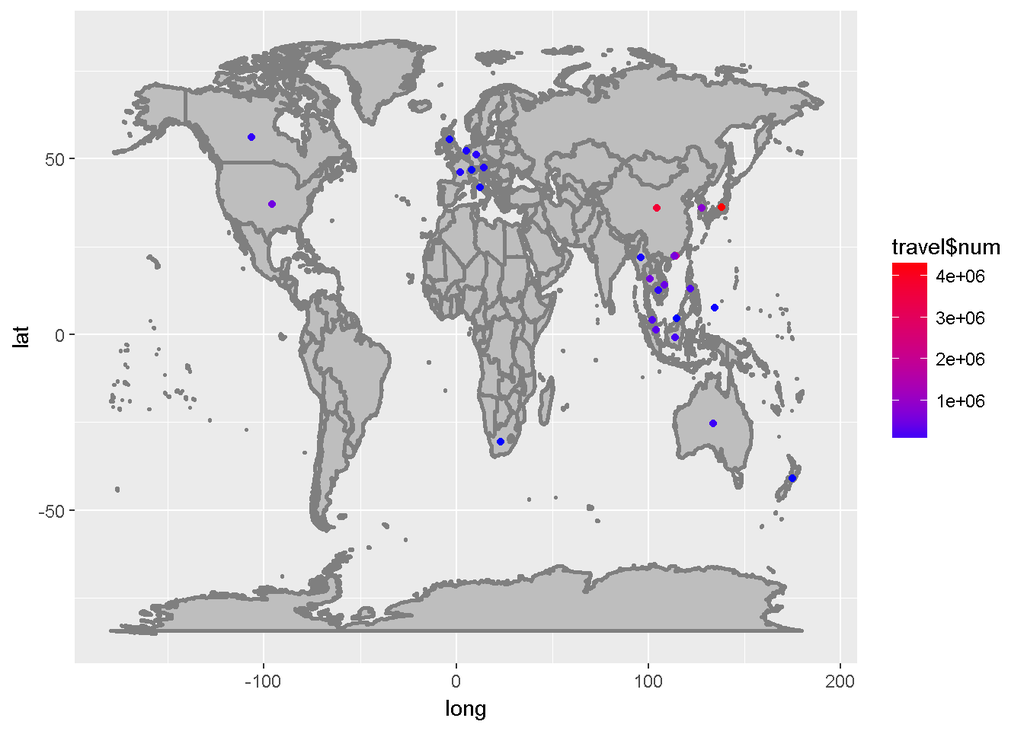

```r
#利用疊圖的方式，將world_map，和geom_point()利用剛剛的經緯度產生的點疊再一起，並利用顏色來區分個數
travel_world=ggplot()+
            world_map+
            geom_point(aes(x=travel_geo$lon, y=travel_geo$lat,color=travel$num))+
            scale_color_continuous(low = "blue",high = "red")+
            guides(size=FALSE)


travel_world
```

##資料分析3:台灣到日本旅遊的人數變化

```r
tojapan<-data.frame(year=c(2002:2016),num=0)
for(i in 1:15){
  tojapan[i,2]=`aborad(taiwan2016).xls`[4,i+2]
}
#建立一個資料表，將到日本旅遊的人數資料逐年讀入

tojapan$num<-as.numeric(tojapan$num)
#將人數資料轉為數值

knitr::kable(tojapan)
```

| year | num |
| --- | --- |
| 2002 | 797460 |
| 2003 | 731330 |
| 2004 | 1051954 |
| 2005 | 1180406 |
| 2006 | 1214058 |
| 2007 | 1280853 |
| 2008 | 1309847 |
| 2009 | 1113857 |
| 2010 | 1377957 |
| 2011 | 1136394 |
| 2012 | 1560300 |
| 2013 | 2346007 |
| 2014 | 2971846 |
| 2015 | 3797879 |
| 2016 | 4295240 |

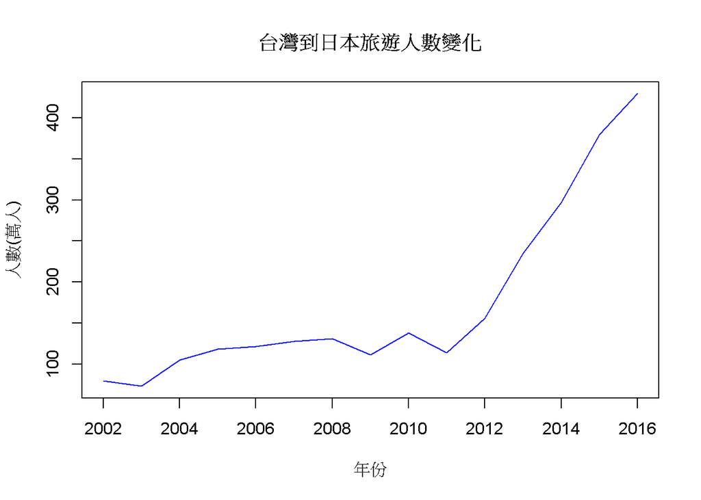

```r
plot(tojapan$year, tojapan$num/10000, type="l",xlim=c(2002,2016),col="blue",main="台灣到日本旅遊人數變化",xlab="年份",ylab="人數(萬人)")
```

```r
#以年分為X軸、人數為Y軸做折線圖分析
```

## 資料分析4:到仙台旅遊的人數變化

```r
sendai_passengers<-data.frame(year=c(2000,2001,2002,2003,
                                    2004,2005,2006,2007,
                                    2008,2009,2010,2011,
                                    2012,2013,2014,2015),
                             num=c(as.numeric(`2000國內定期航空(旅客流動).xls`[nrow(`2000國內定期航空(旅客流動).xls`),20]),
                                   as.numeric(`2001國內定期航空(旅客流動).xls`[nrow(`2001國內定期航空(旅客流動).xls`),20]),
                                   as.numeric(`2002國內定期航空(旅客流動).xls`[nrow(`2002國內定期航空(旅客流動).xls`),20]),
                                   as.numeric(`2003國內定期航空(旅客流動).xls`[nrow(`2003國內定期航空(旅客流動).xls`),20]),
                                   as.numeric(`2004國內定期航空(旅客流動).xls`[nrow(`2004國內定期航空(旅客流動).xls`),20]),
                                   as.numeric(`2005國內定期航空(旅客流動).xls`[nrow(`2005國內定期航空(旅客流動).xls`),20]),
                                   as.numeric(`2006國內定期航空(旅客流動).xls`[nrow(`2006國內定期航空(旅客流動).xls`),20]),
                                   as.numeric(`2007國內定期航空(旅客流動).xls`[nrow(`2007國內定期航空(旅客流動).xls`),22]),
                                   as.numeric(`2008國內定期航空(旅客流動).xls`[nrow(`2008國內定期航空(旅客流動).xls`),22]),
                                   as.numeric(`2009國內定期航空(旅客流動).xls`[nrow(`2009國內定期航空(旅客流動).xls`),22]),
                                   as.numeric(`2010國內定期航空(旅客流動).xls`[nrow(`2010國內定期航空(旅客流動).xls`),22]),
                                   as.numeric(`2011國內定期航空(旅客流動).xls`[nrow(`2011國內定期航空(旅客流動).xls`),22]),
                                   as.numeric(`2012國內定期航空(旅客流動).xls`[nrow(`2012國內定期航空(旅客流動).xls`),22]),
                                   as.numeric(`2013國內定期航空(旅客流動).xls`[nrow(`2013國內定期航空(旅客流動).xls`),22]),
                                   as.numeric(`2014國內定期航空(旅客流動).xls`[nrow(`2014國內定期航空(旅客流動).xls`),22]),
                                   as.numeric(`2015國內定期航空(旅客流動).xls`[nrow(`2015國內定期航空(旅客流動).xls`),22])))

knitr::kable(sendai_passengers)
```

| year | num |
| --- | --- |
| 2000 | 1391783 |
| 2001 | 1400525 |
| 2002 | 1392503 |
| 2003 | 1392503 |
| 2004 | 1437757 |
| 2005 | 1435108 |
| 2006 | 1458894 |
| 2007 | 1445432 |
| 2008 | 1333990 |
| 2009 | 1225379 |
| 2010 | 1222577 |
| 2011 | 768594 |
| 2012 | 1193589 |
| 2013 | 1436527 |
| 2014 | 1469142 |
| 2015 | 1469142 |

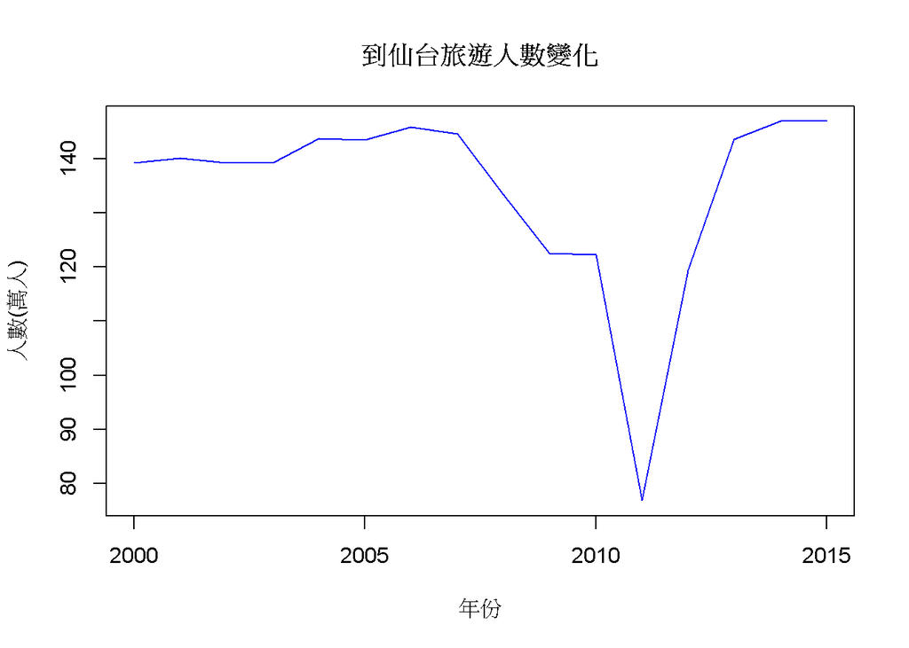

```r
#建立一個只有年分、人數的資料表

plot(sendai_passengers$year, sendai_passengers$num/10000, type = "l",xlim=c(2000,2015),col="blue",main="到仙台旅遊人數變化",xlab="年份",ylab="人數(萬人)")
```

```r
#以年分為X軸、人數為Y軸做折線圖分析
```

## 資料分析5:到福島旅遊的人數變化

```r
fukushima_passengers<-data.frame(year=c(2000,2001,2002,2003,
                                    2004,2005,2006,2007,
                                    2008,2009,2010,2011,
                                    2012,2013,2014,2015),
num=c(as.numeric(`2000國內定期航空(旅客流動).xls`[nrow(`2000國內定期航空(旅客流動).xls`),25]),
                                   as.numeric(`2001國內定期航空(旅客流動).xls`[nrow(`2001國內定期航空(旅客流動).xls`),25]),
                                   as.numeric(`2002國內定期航空(旅客流動).xls`[nrow(`2002國內定期航空(旅客流動).xls`),25]),
                                   as.numeric(`2003國內定期航空(旅客流動).xls`[nrow(`2003國內定期航空(旅客流動).xls`),25]),
                                   as.numeric(`2004國內定期航空(旅客流動).xls`[nrow(`2004國內定期航空(旅客流動).xls`),25]),
                                   as.numeric(`2005國內定期航空(旅客流動).xls`[nrow(`2005國內定期航空(旅客流動).xls`),25]),
                                   as.numeric(`2006國內定期航空(旅客流動).xls`[nrow(`2006國內定期航空(旅客流動).xls`),25]),
                                   as.numeric(`2007國內定期航空(旅客流動).xls`[nrow(`2007國內定期航空(旅客流動).xls`),27]),
                                   as.numeric(`2008國內定期航空(旅客流動).xls`[nrow(`2008國內定期航空(旅客流動).xls`),27]),
                                   as.numeric(`2009國內定期航空(旅客流動).xls`[nrow(`2009國內定期航空(旅客流動).xls`),27]),
                                   as.numeric(`2010國內定期航空(旅客流動).xls`[nrow(`2010國內定期航空(旅客流動).xls`),27]),
                                   as.numeric(`2011國內定期航空(旅客流動).xls`[nrow(`2011國內定期航空(旅客流動).xls`),27]),
                                   as.numeric(`2012國內定期航空(旅客流動).xls`[nrow(`2012國內定期航空(旅客流動).xls`),27]),
                                   as.numeric(`2013國內定期航空(旅客流動).xls`[nrow(`2013國內定期航空(旅客流動).xls`),27]),
                                   as.numeric(`2014國內定期航空(旅客流動).xls`[nrow(`2014國內定期航空(旅客流動).xls`),27]),
                                   as.numeric(`2015國內定期航空(旅客流動).xls`[nrow(`2015國內定期航空(旅客流動).xls`),27])))

knitr::kable(fukushima_passengers)
```

| year | num |
| --- | --- |
| 2000 | 310818 |
| 2001 | 286172 |
| 2002 | 258209 |
| 2003 | 258209 |
| 2004 | 247068 |
| 2005 | 236184 |
| 2006 | 215680 |
| 2007 | 209802 |
| 2008 | 188608 |
| 2009 | 106668 |
| 2010 | 102047 |
| 2011 | 98589 |
| 2012 | 107329 |
| 2013 | 115892 |
| 2014 | 118093 |
| 2015 | 118093 |

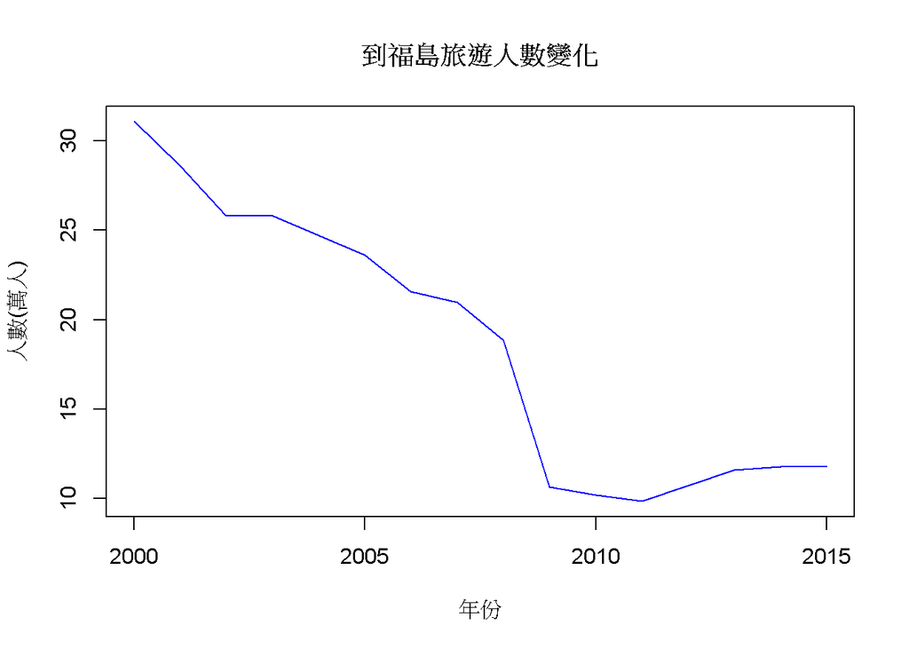

```r
#建立一個只有年分、人數的資料表

plot(fukushima_passengers$year, fukushima_passengers$num/10000, type = "l",xlim=c(2000,2015),col="blue",main="到福島旅遊人數變化",xlab="年份",ylab="人數(萬人)")
```

```r
#以年分為X軸、人數為Y軸做折線圖分析
```

=================================================================

五、分析結果  
1.桃園機場各航空公司的誤點狀況:  
>入境最不準時的六大航空公司:捷星太平洋、遠東航空、四川、全亞洲、德威、濟州  
>出境最不準時的六大航空公司:義大利、捷星太平洋、吉祥、濟州、遠東、捷星日本  
>入境最準時的六大航空公司:景成、酷航、聯合、歐洲、酷島、易斯達  
>出境最準時的六大航空公司:加拿大、法國、馬亞洲、阿聯酋、景成、德威  
>總結:出入境的誤點比例部分呈現正相關(由於資料僅為短期，因此仍須長期觀察才能得出較有參考價值的結論)

2.台灣到各國旅遊的分布圖:  
>日本、中國旅遊人數明顯比其他地區多 >美國、港澳及東南亞地區人數次多  
>總結:旅遊人數大多集中在亞洲

3.台灣到日本旅遊的人數變化:  
>2009年金融風暴後去日本的人數大幅下降  
>2011年311大地震後去日本的人數再次下降 >2012年後到日本旅遊人數人數穩定回升  
>總結:天災人禍確實會影響去日本旅遊的人數

=================================================================

六、分析結果可能解決的問題  
1.桃園機場各航空公司的誤點狀況:  
>盡量避開上述的航空公司(但由於資料較短期，因此仍長期觀察才能得出較有參考價值的結論)

2.台灣到各國旅遊的分布圖:  
>日本、中國旅遊人數較多，因此若需到該地區旅遊，應提前購買機票

3.台灣/日本國內旅遊人數變化:  
>天災是無法避免的災害，因此我們並沒辦法提出確切的結果來解決，因此若不幸的發生了，我們只能等待災區重振，恢復觀光

=================================================================

七、組員名單及分工

B0344218葉建夆  
>資料蒐集(桃園機場)  
>資料分析1、2、3  
>投影片內容大綱

B0344117沈庭安  
>資料蒐集(台灣人旅遊目的地、日本境內航班)  
>資料分析3、4、5  
>投影片完成及校正

=================================================================